# Accuracy in facial trustworthiness impressions: Kernel of truth or modern physiognomy. A meta-analysis. Face-level analysis

Electronic Supplementary Material

omitted for blind review

17 November 2020

```r
# to install orchaRd pacakge

# install.packages('devtools') install.packages('tidyverse')
# install.packages('metafor') install.packages('patchwork')
# install.packages('R.rsp')

# devtools::install_github('itchyshin/orchard_plot', subdir = 'orchaRd',
# force = TRUE, build_vignettes = TRUE)

# Load required packages.

library(tidyverse)  #Tidy family and related packages
library(metafor)  #Meta-analysis package
library(MCMCglmm)  #Bayesian mixed model package
library(MuMIn)  #Model selection and averaging package
library(viridis)  #Nice colours
library(kableExtra)  #For making nice tables
library(psych)  #Certain calculations
library(matrixcalc)  #For generating variance covariance matrices
library(Matrix)  #For generating variance covariance matrices
library(orchaRd)  #Functions for I^2 and R^2
library(patchwork)  #For orchaRd package
library(nlme)  #GLS models
```

## Accuracy in facial trustworthiness impressions dataset - The face level dataset

### Table of the dataset

```r
# Load dataset
data <- read.csv("DataTrustMA.csv", na.strings = "")

# drop any empty rows
data <- data[is.na(data$Ref) == FALSE, ]

# subset to useful data
keepVars <- c("Year", "Paper", "FaceSample", "ParticipantSample", "GTOpRecode",
    "RespMethRecode", "OverallDomain", "PhotoTypeRecode", "Point_of_Decision",
    "UseFirstVersion", "PhotoSource", "UnitOfAnalysis", "N", "N_Observers",
    "final_r")

data <- data[, keepVars]

# subset only the face-level effects
data <- data[data$UnitOfAnalysis == "Face", ]

# when we do this, we end up with some retained levels within factors which
# are no longer used. We can get rid of these using droplevels():
data <- droplevels(data)

# examine data
str(data)
```

```
## 'data.frame':    34 obs. of  15 variables:
##  $ Year             : int  1994 2013 2009 2009 2001 2001 2015 2015 2013 2012 ...
##  $ Paper            : Factor w/ 16 levels "Paper1","Paper10",..: 12 14 15 15 16 16 2 2 3 4 ...
##  $ FaceSample       : Factor w/ 22 levels "sample1","sample10",..: 19 21 20 20 22 22 2 2 3 4 ...
##  $ ParticipantSample: Factor w/ 31 levels "sample1","sample10",..: 30 2 3 4 6 6 7 8 9 11 ...
##  $ GTOpRecode       : Factor w/ 2 levels "Behavioural ",..: 1 1 1 1 1 1 2 2 2 1 ...
##  $ RespMethRecode   : Factor w/ 1 level "Explicit": 1 1 1 1 1 1 1 1 1 1 ...
##  $ OverallDomain    : Factor w/ 6 levels "Aggressiveness",..: 5 4 1 1 5 5 6 6 4 4 ...
##  $ PhotoTypeRecode  : Factor w/ 2 levels "computer","original": 2 2 2 2 2 2 2 2 2 2 ...
##  $ Point_of_Decision: Factor w/ 2 levels "No","Yes": 1 1 1 1 1 1 1 1 1 2 ...
##  $ UseFirstVersion  : int  1 1 0 0 1 1 1 1 1 1 ...
##  $ PhotoSource      : Factor w/ 4 levels "ID card","lab",..: 2 2 2 2 1 1 2 2 2 2 ...
##  $ UnitOfAnalysis   : Factor w/ 1 level "Face": 1 1 1 1 1 1 1 1 1 1 ...
##  $ N                : int  133 80 24 24 85 85 34 34 193 67 ...
##  $ N_Observers      : int  22 80 31 16 24 24 21 15 10 62 ...
##  $ final_r          : num  -0.2 -0.0837 0.42 0.31 0.08 ...
```

```r
names(data)
```

```
##  [1] "Year"              "Paper"             "FaceSample"
##  [4] "ParticipantSample" "GTOpRecode"        "RespMethRecode"
##  [7] "OverallDomain"     "PhotoTypeRecode"   "Point_of_Decision"
## [10] "UseFirstVersion"   "PhotoSource"       "UnitOfAnalysis"
## [13] "N"                 "N_Observers"       "final_r"
```

```r
# fisher's z transform r values
data$Zr <- fisherz(data$final_r)

# compute w (weight)
data$w <- data$N - 3

# making a scrollable table
kable(data, "html") %>% kable_styling("striped", position = "left") %>% scroll_box(width = "100%",
    height = "500px")
```

|  | Year | Paper | FaceSample | ParticipantSample | GTOpRecode | RespMethRecode | OverallDomain | PhotoTypeRecode | Point_of_Decision | UseFirstVersion | PhotoSource | UnitOfAnalysis | N | N_Observers | final_r | Zr | w |
| --- | --- | --- | --- | --- | --- | --- | --- | --- | --- | --- | --- | --- | --- | --- | --- | --- | --- |
| 1 | 1994 | Paper3 | sample5 | sample6 | Behavioural | Explicit | Honesty | original | No | 1 | lab | Face | 133 | 22 | -0.2000000 | -0.2027326 | 130 |
| 5 | 2013 | Paper5 | sample8 | sample10 | Behavioural | Explicit | Economic | original | No | 1 | lab | Face | 80 | 80 | -0.0836739 | -0.0838700 | 77 |
| 10 | 2009 | Paper7 | sample7 | sample15 | Behavioural | Explicit | Aggressiveness | original | No | 0 | lab | Face | 24 | 31 | 0.4200000 | 0.4476920 | 21 |
| 12 | 2009 | Paper7 | sample7 | sample16 | Behavioural | Explicit | Aggressiveness | original | No | 0 | lab | Face | 24 | 16 | 0.3100000 | 0.3205454 | 21 |
| 20 | 2001 | Paper9 | sample9 | sample23 | Behavioural | Explicit | Honesty | original | No | 1 | ID card | Face | 85 | 24 | 0.0800000 | 0.0801713 | 82 |
| 21 | 2001 | Paper9 | sample9 | sample23 | Behavioural | Explicit | Honesty | original | No | 1 | ID card | Face | 85 | 24 | 0.1000000 | 0.1003353 | 82 |
| 23 | 2015 | Paper10 | sample10 | sample24 | Self/other report | Explicit | Sexual | original | No | 1 | lab | Face | 34 | 21 | -0.0800000 | -0.0801713 | 31 |
| 24 | 2015 | Paper10 | sample10 | sample25 | Self/other report | Explicit | Sexual | original | No | 1 | lab | Face | 34 | 15 | 0.0500000 | 0.0500417 | 31 |
| 26 | 2013 | Paper13 | sample14 | sample29 | Self/other report | Explicit | Economic | original | No | 1 | lab | Face | 193 | 10 | 0.2480000 | 0.2532806 | 190 |
| 28 | 2012 | Paper16 | sample17 | sample31 | Behavioural | Explicit | Economic | original | Yes | 1 | lab | Face | 67 | 62 | 0.0530000 | 0.0530497 | 64 |
| 35 | 2013 | Paper25 | sample25 | sample45 | Behavioural | Explicit | Criminal | original | No | 1 | mugshot | Face | 76 | 40 | 0.7241379 | 0.9162907 | 73 |
| 37 | 2013 | Paper25 | sample25 | sample46 | Behavioural | Explicit | Criminal | original | No | 1 | media | Face | 76 | 41 | -0.0549170 | -0.0549723 | 73 |
| 39 | 2013 | Paper25 | sample26 | sample47 | Behavioural | Explicit | Criminal | original | No | 1 | media | Face | 30 | 50 | 0.1191452 | 0.1197139 | 27 |
| 41 | 2013 | Paper25 | sample27 | sample48 | Behavioural | Explicit | Criminal | original | No | 1 | media | Face | 50 | 50 | 0.0896377 | 0.0898789 | 47 |
| 43 | 2013 | Paper25 | sample28 | sample49 | Behavioural | Explicit | Honesty | original | No | 1 | lab | Face | 46 | 50 | 0.0600000 | 0.0600722 | 43 |
| 45 | 2013 | Paper25 | sample28 | sample50 | Behavioural | Explicit | Honesty | original | No | 1 | lab | Face | 46 | 50 | -0.0380000 | -0.0380183 | 43 |
| 46 | 1993 | Paper26 | sample29 | sample51 | Self/other report | Explicit | Aggressiveness | original | No | 1 | lab | Face | 22 | 38 | 0.2100000 | 0.2131713 | 19 |
| 47 | 1993 | Paper26 | sample29 | sample52 | Self/other report | Explicit | Aggressiveness | original | No | 1 | lab | Face | 22 | 40 | 0.1200000 | 0.1205810 | 19 |
| 48 | 2013 | Paper27 | sample30 | sample53 | Self/other report | Explicit | Sexual | original | No | 1 | lab | Face | 101 | 17 | 0.2490000 | 0.2543464 | 98 |
| 49 | 2013 | Paper27 | sample30 | sample54 | Self/other report | Explicit | Sexual | original | No | 1 | lab | Face | 101 | 17 | -0.0310000 | -0.0310099 | 98 |
| 50 | 2013 | Paper27 | sample10 | sample55 | Self/other report | Explicit | Sexual | original | No | 1 | lab | Face | 88 | 17 | -0.0160000 | -0.0160014 | 85 |
| 51 | 2013 | Paper27 | sample10 | sample55 | Self/other report | Explicit | Sexual | original | No | 1 | lab | Face | 88 | 17 | 0.1250000 | 0.1256572 | 85 |
| 52 | 2013 | Paper27 | sample10 | sample56 | Self/other report | Explicit | Sexual | original | No | 1 | lab | Face | 88 | 17 | 0.2640000 | 0.2704032 | 85 |
| 53 | 2013 | Paper27 | sample10 | sample56 | Self/other report | Explicit | Sexual | original | No | 1 | lab | Face | 88 | 17 | -0.0780000 | -0.0781588 | 85 |
| 54 | 2006 | Paper29 | sample32 | sample58 | Self/other report | Explicit | Agreeableness | original | No | 1 | lab | Face | 146 | 10 | 0.0070000 | 0.0070001 | 143 |
| 55 | 2006 | Paper29 | sample33 | sample59 | Self/other report | Explicit | Agreeableness | original | No | 1 | lab | Face | 148 | 10 | -0.0240000 | -0.0240046 | 145 |
| 58 | 2015 | Paper32 | sample37 | sample64 | Behavioural | Explicit | Economic | original | No | 1 | lab | Face | 90 | 30 | 0.2200000 | 0.2236561 | 87 |
| 65 | 1991 | Paper1 | sample1 | sample1 | Self/other report | Explicit | Agreeableness | original | No | 1 | lab | Face | 43 | 38 | 0.3400000 | 0.3540925 | 40 |
| 66 | 1991 | Paper1 | sample2 | sample2 | Self/other report | Explicit | Agreeableness | original | No | 1 | lab | Face | 43 | 33 | 0.1400000 | 0.1409256 | 40 |
| 67 | 1990 | Paper2 | sample3 | sample3 | Self/other report | Explicit | Honesty | original | No | 1 | lab | Face | 40 | 48 | 0.4200000 | 0.4476920 | 37 |
| 68 | 1990 | Paper2 | sample3 | sample4 | Self/other report | Explicit | Agreeableness | original | No | 1 | lab | Face | 26 | 19 | 0.4500000 | 0.4847003 | 23 |
| 69 | 1990 | Paper2 | sample4 | sample5 | Self/other report | Explicit | Agreeableness | original | No | 1 | lab | Face | 26 | 19 | 0.2500000 | 0.2554128 | 23 |
| 70 | 2013 | Paper20 | sample19 | sample36 | Behavioural | Explicit | Aggressiveness | original | No | 1 | media | Face | 146 | 618 | 0.2030000 | 0.2058595 | 143 |
| 71 | 2014 | Paper28 | sample31 | sample57 | Self/other report | Explicit | Agreeableness | computer | No | 1 | lab | Face | 90 | 62 | 0.0900000 | 0.0902442 | 87 |

```r
# Save dataset for plotting later write.csv(data,
# 'dataForPlotting_face.csv')
```

## Initial data exploration

### Here we do a number of checks on the effect sizes and moderators to make sure that there are no weird data.

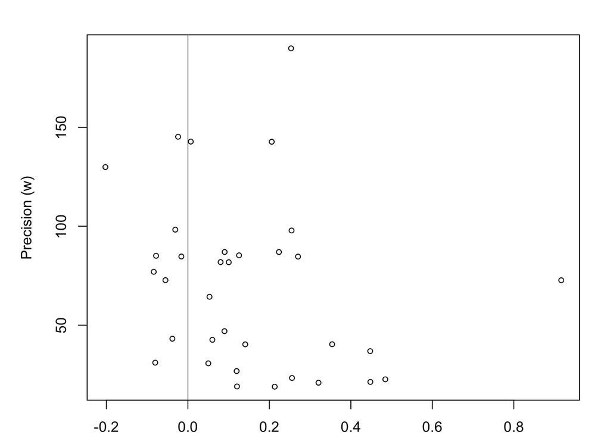

```r
# Plot a funnel plot to view the distribution of the effect sizes by their
# precision (only for initial checking, not used in any analysis)
par(mfcol = c(1, 1), mar = c(2, 4, 2, 1.75), oma = c(0, 1, 0, 0))
plot(jitter(data$Zr), jitter(data$w), cex = 0.75, xlab = "", ylab = "Precision (w)")
abline(v = 0, lwd = 0.5)
```

```r
# Create table that counts the total number of each random factor. This can
# be adapted for any random factors. Note that in this example, we are using
# the 'unique' function to count the number of unique studies and species to
# avoid double counting.

get.table <- function(x) {
    stuff <- c(paste("N_studies = ", length(unique(x$Paper))), paste("N_faceSamples = ",
        length(unique(x$FaceSample))), paste("N_participantSamples = ", length(unique(x$ParticipantSample))),
        paste("N_ES = ", length(x$Zr)))
}

kable(get.table(data), "html") %>% kable_styling("striped", position = "left")
```

| x |
| --- |
| N_studies = 16 |
| N_faceSamples = 22 |
| N_participantSamples = 31 |
| N_ES = 34 |

```r
# simple tables for counting the number of levels of each factor if level
# with smallest number of cases has less than 10% of highest, then can't
# compare

# min = 4, max = 8: fine
levels(data$OverallDomain)
```

```
## [1] "Aggressiveness" "Agreeableness"  "Criminal"       "Economic"
## [5] "Honesty"        "Sexual"
```

```r
table(data$OverallDomain)
```

```
##
## Aggressiveness  Agreeableness       Criminal       Economic        Honesty
##              5              7              4              4              6
##         Sexual
##              8
```

```r
# only one level
levels(data$RespMethRecode)
```

```
## [1] "Explicit"
```

```r
table(data$RespMethRecode)
```

```
##
## Explicit
##       34
```

```r
# min = 15, max = 19: fine
levels(data$GTOpRecode)
```

```
## [1] "Behavioural "      "Self/other report"
```

```r
table(data$GTOpRecode)
```

```
##
##      Behavioural  Self/other report
##                15                19
```

```r
# min = 1, max = 33: don't use
levels(data$PhotoTypeRecode)
```

```
## [1] "computer" "original"
```

```r
table(data$PhotoTypeRecode)
```

```
##
## computer original
##        1       33
```

```r
# min = 1, max = 33: don't use
levels(data$Point_of_Decision)
```

```
## [1] "No"  "Yes"
```

```r
table(data$Point_of_Decision)
```

```
##
##  No Yes
##  33   1
```

```r
# min = 1, max = 27: don't use
levels(data$PhotoSource)
```

```
## [1] "ID card" "lab"     "media"   "mugshot"
```

```r
table(data$PhotoSource)
```

```
##
## ID card     lab   media mugshot
##       2      27       4       1
```

```r
# so our moderators moving forward are Domain and GTOp

# cross-tables to check whether there is any dependence between factors

table(data$GTOpRecode, data$OverallDomain)
```

```
##
##                     Aggressiveness Agreeableness Criminal Economic Honesty
##   Behavioural                    3             0        4        3       5
##   Self/other report              2             7        0        1       1
##
##                     Sexual
##   Behavioural            0
##   Self/other report      8
```

## Meta-analysis

### Here, we are testing whether we need to include the random factors in our meta-analysis models. We will be running likelihood ratio tests to compare models that include the random factors to the intercept-only model. We do this step by step - 1. Test each random factor separately. 2. Include the significant random factors together to see if they improve the model further. Some random factors take theoretical precedance over others. For example, Studyid is usually an important random factor.

### The important stats here for the model comparison is the loglik values.

### Throughout the analysis that we swtich between REML and ML in the specification of the method for the RMA models. We run REML when we want to extract parameter estimates. We run ML when we want to compare models.

```r
# M0: model without random-effects using rma () to calculate I2
# (heterogeneity) vi = precision
res0 <- rma(yi = Zr, vi = 1/w, data = data, method = "REML")  #I^2 = 68.23%
summary(res0)
```

```
##
## Random-Effects Model (k = 34; tau^2 estimator: REML)
##
##   logLik  deviance       AIC       BIC      AICc
##   3.1245   -6.2490   -2.2490    0.7440   -1.8490
##
## tau^2 (estimated amount of total heterogeneity): 0.0311 (SE = 0.0119)
## tau (square root of estimated tau^2 value):      0.1763
## I^2 (total heterogeneity / total variability):   68.23%
## H^2 (total variability / sampling variability):  3.15
##
## Test for Heterogeneity:
## Q(df = 33) = 102.4119, p-val < .0001
##
## Model Results:
##
## estimate      se    zval    pval   ci.lb   ci.ub
##   0.1350  0.0381  3.5398  0.0004  0.0603  0.2098  ***
##
## ---
## Signif. codes:  0 '***' 0.001 '**' 0.01 '*' 0.05 '.' 0.1 ' ' 1
```

```r
# save model object for plotting purposes save(res0, file =
# 'M0_I2_Face.RData')

# M1: model without random-effects intercept-only model)
res1 <- rma.mv(yi = Zr, V = 1/w, data = data, method = "ML")
summary(res1)
```

```
##
## Multivariate Meta-Analysis Model (k = 34; method: ML)
##
##   logLik  Deviance       AIC       BIC      AICc
## -13.6697  102.4119   29.3393   30.8657   29.4643
##
## Variance Components: none
##
## Test for Heterogeneity:
## Q(df = 33) = 102.4119, p-val < .0001
##
## Model Results:
##
## estimate      se    zval    pval   ci.lb   ci.ub
##   0.1184  0.0205  5.7745  <.0001  0.0782  0.1586  ***
##
## ---
## Signif. codes:  0 '***' 0.001 '**' 0.01 '*' 0.05 '.' 0.1 ' ' 1
```

```r
llres1 <- fitstats(res1)[1]

# M2: random-effect model(intercept-only model) with Paper
res2 <- rma.mv(yi = Zr, V = 1/w, random = list(~1 | Paper), data = data, method = "ML")
summary(res2)
```

```
##
## Multivariate Meta-Analysis Model (k = 34; method: ML)
##
##   logLik  Deviance       AIC       BIC      AICc
##  -7.8159   90.7043   19.6318   22.6845   20.0189
##
## Variance Components:
##
##             estim    sqrt  nlvls  fixed  factor
## sigma^2    0.0140  0.1182     16     no   Paper
##
## Test for Heterogeneity:
## Q(df = 33) = 102.4119, p-val < .0001
##
## Model Results:
##
## estimate      se    zval    pval   ci.lb   ci.ub
##   0.1264  0.0382  3.3056  0.0009  0.0514  0.2013  ***
##
## ---
## Signif. codes:  0 '***' 0.001 '**' 0.01 '*' 0.05 '.' 0.1 ' ' 1
```

```r
llres2 <- fitstats(res2)[1]

# adding effect size level random effect
obs <- 1:dim(data)[1]

res2b <- rma.mv(yi = Zr, V = 1/w, random = list(~1 | Paper, ~1 | obs), data = data,
    method = "REML")
summary(res2b)
```

```
##
## Multivariate Meta-Analysis Model (k = 34; method: REML)
##
##   logLik  Deviance       AIC       BIC      AICc
##   3.1245   -6.2490   -0.2490    4.2406    0.5786
##
## Variance Components:
##
##             estim    sqrt  nlvls  fixed  factor
## sigma^2.1  0.0000  0.0000     16     no   Paper
## sigma^2.2  0.0311  0.1763     34     no     obs
##
## Test for Heterogeneity:
## Q(df = 33) = 102.4119, p-val < .0001
##
## Model Results:
##
## estimate      se    zval    pval   ci.lb   ci.ub
##   0.1350  0.0381  3.5398  0.0004  0.0603  0.2098  ***
##
## ---
## Signif. codes:  0 '***' 0.001 '**' 0.01 '*' 0.05 '.' 0.1 ' ' 1
```

```r
i2_ml(res2b)
```

```
##     I2_total     I2_Paper       I2_obs
## 6.822993e-01 1.263989e-10 6.822993e-01
```

```r
# seems like more heterogeneity once you put obs

# one can do likehood ratio test
anova(res1, res2)
```

```
##         df     AIC     BIC    AICc   logLik     LRT   pval       QE
## Full     2 19.6318 22.6845 20.0189  -7.8159                102.4119
## Reduced  1 29.3393 30.8657 29.4643 -13.6697 11.7075 0.0006 102.4119
```

```r
# Likelihood ratio test to test the effect of Paper
(2 * abs(llres1)) - (2 * abs(llres2))
```

```
## [1] 11.70752
```

```r
pchisq(((2 * abs(llres1)) - (2 * abs(llres2))), 1, lower.tail = FALSE)
```

```
## [1] 0.0006224794
```

```r
# significant improvement

# M3: random-effect model(intercept-only model) with FaceSample
res3 <- rma.mv(yi = Zr, V = 1/w, random = list(~1 | FaceSample), data = data,
    method = "ML")
summary(res3)
```

```
##
## Multivariate Meta-Analysis Model (k = 34; method: ML)
##
##   logLik  Deviance       AIC       BIC      AICc
##  -5.7813   86.6351   15.5626   18.6153   15.9497
##
## Variance Components:
##
##             estim    sqrt  nlvls  fixed      factor
## sigma^2    0.0161  0.1270     22     no  FaceSample
##
## Test for Heterogeneity:
## Q(df = 33) = 102.4119, p-val < .0001
##
## Model Results:
##
## estimate      se    zval    pval   ci.lb   ci.ub
##   0.1321  0.0360  3.6703  0.0002  0.0616  0.2026  ***
##
## ---
## Signif. codes:  0 '***' 0.001 '**' 0.01 '*' 0.05 '.' 0.1 ' ' 1
```

```r
llres3 <- fitstats(res3)[1]

# obs in
res3b <- rma.mv(yi = Zr, V = 1/w, random = list(~1 | FaceSample, ~1 | obs),
    data = data, method = "REML")
summary(res3b)
```

```
##
## Multivariate Meta-Analysis Model (k = 34; method: REML)
##
##   logLik  Deviance       AIC       BIC      AICc
##   3.1245   -6.2490   -0.2490    4.2406    0.5786
##
## Variance Components:
##
##             estim    sqrt  nlvls  fixed      factor
## sigma^2.1  0.0000  0.0000     22     no  FaceSample
## sigma^2.2  0.0311  0.1763     34     no         obs
##
## Test for Heterogeneity:
## Q(df = 33) = 102.4119, p-val < .0001
##
## Model Results:
##
## estimate      se    zval    pval   ci.lb   ci.ub
##   0.1350  0.0381  3.5398  0.0004  0.0603  0.2098  ***
##
## ---
## Signif. codes:  0 '***' 0.001 '**' 0.01 '*' 0.05 '.' 0.1 ' ' 1
```

```r
i2_ml(res3b)
```

```
##      I2_total I2_FaceSample        I2_obs
##  6.822993e-01  7.814913e-10  6.822993e-01
```

```r
# very similar - all the variation is in obs

# Likelihood ratio test to test the effect of FaceSample
(2 * -(llres1)) - (2 * -(llres3))
```

```
## [1] 15.77673
```

```r
pchisq(((2 * -(llres1)) - (2 * -(llres3))), 1, lower.tail = FALSE)
```

```
## [1] 7.127393e-05
```

```r
# significant improvement

# M4: random-effect model(intercept-only model) with ParticipantSample
res4 <- rma.mv(yi = Zr, V = 1/w, random = list(~1 | ParticipantSample), data = data,
    method = "ML")
summary(res4)
```

```
##
## Multivariate Meta-Analysis Model (k = 34; method: ML)
##
##   logLik  Deviance       AIC       BIC      AICc
##   2.7358   69.6009   -1.4716    1.5811   -1.0845
##
## Variance Components:
##
##             estim    sqrt  nlvls  fixed             factor
## sigma^2    0.0308  0.1755     31     no  ParticipantSample
##
## Test for Heterogeneity:
## Q(df = 33) = 102.4119, p-val < .0001
##
## Model Results:
##
## estimate      se    zval    pval   ci.lb   ci.ub
##   0.1401  0.0398  3.5212  0.0004  0.0621  0.2180  ***
##
## ---
## Signif. codes:  0 '***' 0.001 '**' 0.01 '*' 0.05 '.' 0.1 ' ' 1
```

```r
llres4 <- fitstats(res4)[1]

# obs in
res4b <- rma.mv(yi = Zr, V = 1/w, random = list(~1 | ParticipantSample, ~1 |
    obs), data = data, method = "REML")
summary(res4b)
```

```
##
## Multivariate Meta-Analysis Model (k = 34; method: REML)
##
##   logLik  Deviance       AIC       BIC      AICc
##   3.1245   -6.2490   -0.2490    4.2406    0.5786
##
## Variance Components:
##
##             estim    sqrt  nlvls  fixed             factor
## sigma^2.1  0.0000  0.0000     31     no  ParticipantSample
## sigma^2.2  0.0311  0.1763     34     no                obs
##
## Test for Heterogeneity:
## Q(df = 33) = 102.4119, p-val < .0001
##
## Model Results:
##
## estimate      se    zval    pval   ci.lb   ci.ub
##   0.1350  0.0381  3.5398  0.0004  0.0603  0.2098  ***
##
## ---
## Signif. codes:  0 '***' 0.001 '**' 0.01 '*' 0.05 '.' 0.1 ' ' 1
```

```r
i2_ml(res4b)
```

```
##             I2_total I2_ParticipantSample               I2_obs
##         6.822993e-01         6.906558e-10         6.822993e-01
```

```r
# ParticipantSample is close to obs - so res4 is pretty much the same as
# having just ~|obs

# Likelihood ratio test to test the effect of ParticipantSample
(2 * -(llres1)) - (2 * -(llres4))
```

```
## [1] 32.81099
```

```r
pchisq(((2 * -(llres1)) - (2 * -(llres4))), 1, lower.tail = FALSE)
```

```
## [1] 1.01569e-08
```

```r
# significant improvement

# M5: random-effect model(intercept-only model) with ParticipantSample
# nested within Paper
res5 <- rma.mv(yi = Zr, V = 1/w, random = list(~1 | Paper/ParticipantSample),
    data = data, method = "ML")
summary(res5)
```

```
##
## Multivariate Meta-Analysis Model (k = 34; method: ML)
##
##   logLik  Deviance       AIC       BIC      AICc
##   2.7358   69.6009    0.5284    5.1074    1.3284
##
## Variance Components:
##
##             estim    sqrt  nlvls  fixed                   factor
## sigma^2.1  0.0000  0.0000     16     no                    Paper
## sigma^2.2  0.0308  0.1755     31     no  Paper/ParticipantSample
##
## Test for Heterogeneity:
## Q(df = 33) = 102.4119, p-val < .0001
##
## Model Results:
##
## estimate      se    zval    pval   ci.lb   ci.ub
##   0.1401  0.0398  3.5212  0.0004  0.0621  0.2180  ***
##
## ---
## Signif. codes:  0 '***' 0.001 '**' 0.01 '*' 0.05 '.' 0.1 ' ' 1
```

```r
llres5 <- fitstats(res5)[1]

# Enter the random effects individually rather than nested
res5b <- rma.mv(yi = Zr, V = 1/w, random = list(~1 | Paper, ~1 | ParticipantSample),
    data = data, method = "ML")
summary(res5b)
```

```
##
## Multivariate Meta-Analysis Model (k = 34; method: ML)
##
##   logLik  Deviance       AIC       BIC      AICc
##   2.7358   69.6009    0.5284    5.1074    1.3284
##
## Variance Components:
##
##             estim    sqrt  nlvls  fixed             factor
## sigma^2.1  0.0000  0.0000     16     no              Paper
## sigma^2.2  0.0308  0.1755     31     no  ParticipantSample
##
## Test for Heterogeneity:
## Q(df = 33) = 102.4119, p-val < .0001
##
## Model Results:
##
## estimate      se    zval    pval   ci.lb   ci.ub
##   0.1401  0.0398  3.5212  0.0004  0.0621  0.2180  ***
##
## ---
## Signif. codes:  0 '***' 0.001 '**' 0.01 '*' 0.05 '.' 0.1 ' ' 1
```

```r
# random=list(~1|Paper/ParticipantSample) is pretty much the same as the
# model with random=list(~1|Paper, ~1|obs) and the exactly the same as
# random=list(~1|Paper, ~1|ParticipantSample)

# Likelihood ratio test to test if ParticipantSample has a significant
# effect beyond Paper
(2 * -(llres2)) - (2 * -(llres5))
```

```
## [1] 21.10347
```

```r
pchisq(((2 * -(llres2)) - (2 * -(llres5))), 1, lower.tail = FALSE)
```

```
## [1] 4.3514e-06
```

```r
# significant improvement

# M6: random-effect model(intercept-only model) with Paper, FaceSample and
# ParticipantSample
res6 <- rma.mv(yi = Zr, V = 1/w, random = list(~1 | Paper/ParticipantSample,
    ~1 | FaceSample), data = data, method = "ML")
summary(res6)
```

```
##
## Multivariate Meta-Analysis Model (k = 34; method: ML)
##
##   logLik  Deviance       AIC       BIC      AICc
##   2.7358   69.6009    2.5284    8.6338    3.9077
##
## Variance Components:
##
##             estim    sqrt  nlvls  fixed                   factor
## sigma^2.1  0.0000  0.0000     16     no                    Paper
## sigma^2.2  0.0308  0.1755     31     no  Paper/ParticipantSample
## sigma^2.3  0.0000  0.0000     22     no               FaceSample
##
## Test for Heterogeneity:
## Q(df = 33) = 102.4119, p-val < .0001
##
## Model Results:
##
## estimate      se    zval    pval   ci.lb   ci.ub
##   0.1401  0.0398  3.5212  0.0004  0.0621  0.2180  ***
##
## ---
## Signif. codes:  0 '***' 0.001 '**' 0.01 '*' 0.05 '.' 0.1 ' ' 1
```

```r
llres6 <- fitstats(res6)[1]

# Likelihood ratio test to test if FaceSample has a significant effect
# beyond Paper and ParticipantSample
(2 * -(llres5)) - (2 * -(llres6))
```

```
## [1] -7.683738e-10
```

```r
pchisq(((2 * -(llres5)) - (2 * -(llres6))), 1, lower.tail = FALSE)
```

```
## [1] 1
```

```r
# no significant improvement

# M7: random-effect model(intercept-only model) with Paper and
# ParticipantSample using REML for parameter estimate
res7 <- rma.mv(yi = Zr, V = 1/w, random = list(~1 | Paper/ParticipantSample),
    data = data, method = "REML")
i2_ml(res7)
```

```
##                   I2_total                   I2_Paper
##               6.913608e-01               9.751175e-11
## I2_Paper/ParticipantSample
##               6.913608e-01
```

```r
summary(res7)
```

```
##
## Multivariate Meta-Analysis Model (k = 34; method: REML)
##
##   logLik  Deviance       AIC       BIC      AICc
##   2.2018   -4.4037    1.5963    6.0859    2.4239
##
## Variance Components:
##
##             estim    sqrt  nlvls  fixed                   factor
## sigma^2.1  0.0000  0.0000     16     no                    Paper
## sigma^2.2  0.0324  0.1800     31     no  Paper/ParticipantSample
##
## Test for Heterogeneity:
## Q(df = 33) = 102.4119, p-val < .0001
##
## Model Results:
##
## estimate      se    zval    pval   ci.lb   ci.ub
##   0.1405  0.0405  3.4725  0.0005  0.0612  0.2198  ***
##
## ---
## Signif. codes:  0 '***' 0.001 '**' 0.01 '*' 0.05 '.' 0.1 ' ' 1
```

```r
# This is the average effect size after controlling for the random factor.
# Note the transform function that converts the Z values to R.
predict(res7, transf = transf.ztor)
```

```
##    pred  ci.lb  ci.ub   cr.lb  cr.ub
##  0.1396 0.0611 0.2163 -0.2176 0.4638
```

```r
# save Zr results for plotting purposes save(res7, file =
# 'M0_res_Face.RData')
```

## Meta-regression models with individual moderators

### We run individual meta-regression models with each of the individual moderators to extract the effect size estimates for each of the moderator levels.

```r
# Mixed-effect model with OverallDomain (the '-1' after the factor gets rid
# of the intercept. So the results represent the mean effect size of each
# level of the moderator)
res8 <- rma.mv(yi = Zr, V = 1/w, random = list(~1 | Paper/ParticipantSample),
    mods = ~factor(OverallDomain) - 1, data = data, method = "REML")
summary(res8)
```

```
##
## Multivariate Meta-Analysis Model (k = 34; method: REML)
##
##   logLik  Deviance       AIC       BIC      AICc
##   1.6679   -3.3358   12.6642   23.3219   20.2432
##
## Variance Components:
##
##             estim    sqrt  nlvls  fixed                   factor
## sigma^2.1  0.0000  0.0069     16     no                    Paper
## sigma^2.2  0.0335  0.1830     31     no  Paper/ParticipantSample
##
## Test for Residual Heterogeneity:
## QE(df = 28) = 83.9559, p-val < .0001
##
## Test of Moderators (coefficient(s) 1:6):
## QM(df = 6) = 15.9253, p-val = 0.0142
##
## Model Results:
##
##                                      estimate      se    zval    pval
## factor(OverallDomain)Aggressiveness    0.2539  0.1174  2.1622  0.0306
## factor(OverallDomain)Agreeableness     0.1491  0.0872  1.7108  0.0871
## factor(OverallDomain)Criminal          0.2886  0.1158  2.4922  0.0127
## factor(OverallDomain)Economic          0.1199  0.1055  1.1365  0.2558
## factor(OverallDomain)Honesty           0.0508  0.0994  0.5105  0.6097
## factor(OverallDomain)Sexual            0.0668  0.0889  0.7510  0.4527
##                                        ci.lb   ci.ub
## factor(OverallDomain)Aggressiveness   0.0238  0.4841  *
## factor(OverallDomain)Agreeableness   -0.0217  0.3199  .
## factor(OverallDomain)Criminal         0.0616  0.5156  *
## factor(OverallDomain)Economic        -0.0869  0.3267
## factor(OverallDomain)Honesty         -0.1441  0.2456
## factor(OverallDomain)Sexual          -0.1075  0.2410
##
## ---
## Signif. codes:  0 '***' 0.001 '**' 0.01 '*' 0.05 '.' 0.1 ' ' 1
```

```r
r2_ml(res8)
```

```
##   R2_marginal R2_coditional
##     0.1819378     0.1831063
```

```r
# save results for plotting purposes save(res8, file =
# 'OverallDomain_res_Face.RData')

# Run the model again with the intercept as one of the levels of the factor.
# Now you are comparing each of the subsequent levels to the
# intercept/reference level
res8a <- rma.mv(yi = Zr, V = 1/w, random = list(~1 | Paper/ParticipantSample),
    mods = ~factor(OverallDomain), data = data, method = "REML")
summary(res8a)
```

```
##
## Multivariate Meta-Analysis Model (k = 34; method: REML)
##
##   logLik  Deviance       AIC       BIC      AICc
##   1.6679   -3.3358   12.6642   23.3219   20.2432
##
## Variance Components:
##
##             estim    sqrt  nlvls  fixed                   factor
## sigma^2.1  0.0000  0.0069     16     no                    Paper
## sigma^2.2  0.0335  0.1830     31     no  Paper/ParticipantSample
##
## Test for Residual Heterogeneity:
## QE(df = 28) = 83.9559, p-val < .0001
##
## Test of Moderators (coefficient(s) 2:6):
## QM(df = 5) = 4.1227, p-val = 0.5319
##
## Model Results:
##
##                                     estimate      se     zval    pval
## intrcpt                               0.2539  0.1174   2.1622  0.0306
## factor(OverallDomain)Agreeableness   -0.1048  0.1463  -0.7168  0.4735
## factor(OverallDomain)Criminal         0.0347  0.1649   0.2103  0.8334
## factor(OverallDomain)Economic        -0.1340  0.1579  -0.8489  0.3960
## factor(OverallDomain)Honesty         -0.2032  0.1539  -1.3205  0.1867
## factor(OverallDomain)Sexual          -0.1872  0.1473  -1.2707  0.2039
##                                       ci.lb   ci.ub
## intrcpt                              0.0238  0.4841  *
## factor(OverallDomain)Agreeableness  -0.3915  0.1818
## factor(OverallDomain)Criminal       -0.2886  0.3580
## factor(OverallDomain)Economic       -0.4435  0.1754
## factor(OverallDomain)Honesty        -0.5048  0.0984
## factor(OverallDomain)Sexual         -0.4759  0.1015
##
## ---
## Signif. codes:  0 '***' 0.001 '**' 0.01 '*' 0.05 '.' 0.1 ' ' 1
```

```r
# Repeat analysis with different ref groups for contrast analysis
res8b <- rma.mv(yi = Zr, V = 1/w, random = list(~1 | Paper/ParticipantSample),
    mods = ~relevel(factor(OverallDomain), ref = 2), data = data, method = "REML")
summary(res8b)
```

```
##
## Multivariate Meta-Analysis Model (k = 34; method: REML)
##
##   logLik  Deviance       AIC       BIC      AICc
##   1.6679   -3.3358   12.6642   23.3219   20.2432
##
## Variance Components:
##
##             estim    sqrt  nlvls  fixed                   factor
## sigma^2.1  0.0000  0.0069     16     no                    Paper
## sigma^2.2  0.0335  0.1830     31     no  Paper/ParticipantSample
##
## Test for Residual Heterogeneity:
## QE(df = 28) = 83.9559, p-val < .0001
##
## Test of Moderators (coefficient(s) 2:6):
## QM(df = 5) = 4.1227, p-val = 0.5319
##
## Model Results:
##
##                                                        estimate      se
## intrcpt                                                  0.1491  0.0872
## relevel(factor(OverallDomain), ref = 2)Aggressiveness    0.1048  0.1463
## relevel(factor(OverallDomain), ref = 2)Criminal          0.1395  0.1449
## relevel(factor(OverallDomain), ref = 2)Economic         -0.0292  0.1369
## relevel(factor(OverallDomain), ref = 2)Honesty          -0.0984  0.1322
## relevel(factor(OverallDomain), ref = 2)Sexual           -0.0823  0.1245
##                                                           zval    pval
## intrcpt                                                 1.7108  0.0871
## relevel(factor(OverallDomain), ref = 2)Aggressiveness   0.7168  0.4735
## relevel(factor(OverallDomain), ref = 2)Criminal         0.9626  0.3357
## relevel(factor(OverallDomain), ref = 2)Economic        -0.2132  0.8311
## relevel(factor(OverallDomain), ref = 2)Honesty         -0.7440  0.4569
## relevel(factor(OverallDomain), ref = 2)Sexual          -0.6613  0.5084
##                                                          ci.lb   ci.ub
## intrcpt                                                -0.0217  0.3199  .
## relevel(factor(OverallDomain), ref = 2)Aggressiveness  -0.1818  0.3915
## relevel(factor(OverallDomain), ref = 2)Criminal        -0.1446  0.4236
## relevel(factor(OverallDomain), ref = 2)Economic        -0.2974  0.2391
## relevel(factor(OverallDomain), ref = 2)Honesty         -0.3575  0.1608
## relevel(factor(OverallDomain), ref = 2)Sexual          -0.3264  0.1617
##
## ---
## Signif. codes:  0 '***' 0.001 '**' 0.01 '*' 0.05 '.' 0.1 ' ' 1
```

```r
res8c <- rma.mv(yi = Zr, V = 1/w, random = list(~1 | Paper/ParticipantSample),
    mods = ~relevel(factor(OverallDomain), ref = 3), data = data, method = "REML")
summary(res8c)
```

```
##
## Multivariate Meta-Analysis Model (k = 34; method: REML)
##
##   logLik  Deviance       AIC       BIC      AICc
##   1.6679   -3.3358   12.6642   23.3219   20.2432
##
## Variance Components:
##
##             estim    sqrt  nlvls  fixed                   factor
## sigma^2.1  0.0000  0.0069     16     no                    Paper
## sigma^2.2  0.0335  0.1830     31     no  Paper/ParticipantSample
##
## Test for Residual Heterogeneity:
## QE(df = 28) = 83.9559, p-val < .0001
##
## Test of Moderators (coefficient(s) 2:6):
## QM(df = 5) = 4.1227, p-val = 0.5319
##
## Model Results:
##
##                                                        estimate      se
## intrcpt                                                  0.2886  0.1158
## relevel(factor(OverallDomain), ref = 3)Aggressiveness   -0.0347  0.1649
## relevel(factor(OverallDomain), ref = 3)Agreeableness    -0.1395  0.1449
## relevel(factor(OverallDomain), ref = 3)Economic         -0.1687  0.1567
## relevel(factor(OverallDomain), ref = 3)Honesty          -0.2379  0.1525
## relevel(factor(OverallDomain), ref = 3)Sexual           -0.2219  0.1460
##                                                           zval    pval
## intrcpt                                                 2.4922  0.0127
## relevel(factor(OverallDomain), ref = 3)Aggressiveness  -0.2103  0.8334
## relevel(factor(OverallDomain), ref = 3)Agreeableness   -0.9626  0.3357
## relevel(factor(OverallDomain), ref = 3)Economic        -1.0768  0.2816
## relevel(factor(OverallDomain), ref = 3)Honesty         -1.5596  0.1188
## relevel(factor(OverallDomain), ref = 3)Sexual          -1.5195  0.1286
##                                                          ci.lb   ci.ub
## intrcpt                                                 0.0616  0.5156  *
## relevel(factor(OverallDomain), ref = 3)Aggressiveness  -0.3580  0.2886
## relevel(factor(OverallDomain), ref = 3)Agreeableness   -0.4236  0.1446
## relevel(factor(OverallDomain), ref = 3)Economic        -0.4758  0.1384
## relevel(factor(OverallDomain), ref = 3)Honesty         -0.5368  0.0611
## relevel(factor(OverallDomain), ref = 3)Sexual          -0.5080  0.0643
##
## ---
## Signif. codes:  0 '***' 0.001 '**' 0.01 '*' 0.05 '.' 0.1 ' ' 1
```

```r
res8d <- rma.mv(yi = Zr, V = 1/w, random = list(~1 | Paper/ParticipantSample),
    mods = ~relevel(factor(OverallDomain), ref = 4), data = data, method = "REML")
summary(res8d)
```

```
##
## Multivariate Meta-Analysis Model (k = 34; method: REML)
##
##   logLik  Deviance       AIC       BIC      AICc
##   1.6679   -3.3358   12.6642   23.3219   20.2432
##
## Variance Components:
##
##             estim    sqrt  nlvls  fixed                   factor
## sigma^2.1  0.0000  0.0069     16     no                    Paper
## sigma^2.2  0.0335  0.1830     31     no  Paper/ParticipantSample
##
## Test for Residual Heterogeneity:
## QE(df = 28) = 83.9559, p-val < .0001
##
## Test of Moderators (coefficient(s) 2:6):
## QM(df = 5) = 4.1227, p-val = 0.5319
##
## Model Results:
##
##                                                        estimate      se
## intrcpt                                                  0.1199  0.1055
## relevel(factor(OverallDomain), ref = 4)Aggressiveness    0.1340  0.1579
## relevel(factor(OverallDomain), ref = 4)Agreeableness     0.0292  0.1369
## relevel(factor(OverallDomain), ref = 4)Criminal          0.1687  0.1567
## relevel(factor(OverallDomain), ref = 4)Honesty          -0.0692  0.1450
## relevel(factor(OverallDomain), ref = 4)Sexual           -0.0532  0.1380
##                                                           zval    pval
## intrcpt                                                 1.1365  0.2558
## relevel(factor(OverallDomain), ref = 4)Aggressiveness   0.8489  0.3960
## relevel(factor(OverallDomain), ref = 4)Agreeableness    0.2132  0.8311
## relevel(factor(OverallDomain), ref = 4)Criminal         1.0768  0.2816
## relevel(factor(OverallDomain), ref = 4)Honesty         -0.4771  0.6333
## relevel(factor(OverallDomain), ref = 4)Sexual          -0.3852  0.7001
##                                                          ci.lb   ci.ub
## intrcpt                                                -0.0869  0.3267
## relevel(factor(OverallDomain), ref = 4)Aggressiveness  -0.1754  0.4435
## relevel(factor(OverallDomain), ref = 4)Agreeableness   -0.2391  0.2974
## relevel(factor(OverallDomain), ref = 4)Criminal        -0.1384  0.4758
## relevel(factor(OverallDomain), ref = 4)Honesty         -0.3533  0.2150
## relevel(factor(OverallDomain), ref = 4)Sexual          -0.3236  0.2173
##
## ---
## Signif. codes:  0 '***' 0.001 '**' 0.01 '*' 0.05 '.' 0.1 ' ' 1
```

```r
res8e <- rma.mv(yi = Zr, V = 1/w, random = list(~1 | Paper/ParticipantSample),
    mods = ~relevel(factor(OverallDomain), ref = 5), data = data, method = "REML")
summary(res8e)
```

```
##
## Multivariate Meta-Analysis Model (k = 34; method: REML)
##
##   logLik  Deviance       AIC       BIC      AICc
##   1.6679   -3.3358   12.6642   23.3219   20.2432
##
## Variance Components:
##
##             estim    sqrt  nlvls  fixed                   factor
## sigma^2.1  0.0000  0.0069     16     no                    Paper
## sigma^2.2  0.0335  0.1830     31     no  Paper/ParticipantSample
##
## Test for Residual Heterogeneity:
## QE(df = 28) = 83.9559, p-val < .0001
##
## Test of Moderators (coefficient(s) 2:6):
## QM(df = 5) = 4.1227, p-val = 0.5319
##
## Model Results:
##
##                                                        estimate      se
## intrcpt                                                  0.0508  0.0994
## relevel(factor(OverallDomain), ref = 5)Aggressiveness    0.2032  0.1539
## relevel(factor(OverallDomain), ref = 5)Agreeableness     0.0984  0.1322
## relevel(factor(OverallDomain), ref = 5)Criminal          0.2379  0.1525
## relevel(factor(OverallDomain), ref = 5)Economic          0.0692  0.1450
## relevel(factor(OverallDomain), ref = 5)Sexual            0.0160  0.1334
##                                                          zval    pval
## intrcpt                                                0.5105  0.6097
## relevel(factor(OverallDomain), ref = 5)Aggressiveness  1.3205  0.1867
## relevel(factor(OverallDomain), ref = 5)Agreeableness   0.7440  0.4569
## relevel(factor(OverallDomain), ref = 5)Criminal        1.5596  0.1188
## relevel(factor(OverallDomain), ref = 5)Economic        0.4771  0.6333
## relevel(factor(OverallDomain), ref = 5)Sexual          0.1201  0.9044
##                                                          ci.lb   ci.ub
## intrcpt                                                -0.1441  0.2456
## relevel(factor(OverallDomain), ref = 5)Aggressiveness  -0.0984  0.5048
## relevel(factor(OverallDomain), ref = 5)Agreeableness   -0.1608  0.3575
## relevel(factor(OverallDomain), ref = 5)Criminal        -0.0611  0.5368
## relevel(factor(OverallDomain), ref = 5)Economic        -0.2150  0.3533
## relevel(factor(OverallDomain), ref = 5)Sexual          -0.2454  0.2774
##
## ---
## Signif. codes:  0 '***' 0.001 '**' 0.01 '*' 0.05 '.' 0.1 ' ' 1
```

```r
res8f <- rma.mv(yi = Zr, V = 1/w, random = list(~1 | Paper/ParticipantSample),
    mods = ~relevel(factor(OverallDomain), ref = 6), data = data, method = "REML")
summary(res8f)
```

```
##
## Multivariate Meta-Analysis Model (k = 34; method: REML)
##
##   logLik  Deviance       AIC       BIC      AICc
##   1.6679   -3.3358   12.6642   23.3219   20.2432
##
## Variance Components:
##
##             estim    sqrt  nlvls  fixed                   factor
## sigma^2.1  0.0000  0.0069     16     no                    Paper
## sigma^2.2  0.0335  0.1830     31     no  Paper/ParticipantSample
##
## Test for Residual Heterogeneity:
## QE(df = 28) = 83.9559, p-val < .0001
##
## Test of Moderators (coefficient(s) 2:6):
## QM(df = 5) = 4.1227, p-val = 0.5319
##
## Model Results:
##
##                                                        estimate      se
## intrcpt                                                  0.0668  0.0889
## relevel(factor(OverallDomain), ref = 6)Aggressiveness    0.1872  0.1473
## relevel(factor(OverallDomain), ref = 6)Agreeableness     0.0823  0.1245
## relevel(factor(OverallDomain), ref = 6)Criminal          0.2219  0.1460
## relevel(factor(OverallDomain), ref = 6)Economic          0.0532  0.1380
## relevel(factor(OverallDomain), ref = 6)Honesty          -0.0160  0.1334
##                                                           zval    pval
## intrcpt                                                 0.7510  0.4527
## relevel(factor(OverallDomain), ref = 6)Aggressiveness   1.2707  0.2039
## relevel(factor(OverallDomain), ref = 6)Agreeableness    0.6613  0.5084
## relevel(factor(OverallDomain), ref = 6)Criminal         1.5195  0.1286
## relevel(factor(OverallDomain), ref = 6)Economic         0.3852  0.7001
## relevel(factor(OverallDomain), ref = 6)Honesty         -0.1201  0.9044
##                                                          ci.lb   ci.ub
## intrcpt                                                -0.1075  0.2410
## relevel(factor(OverallDomain), ref = 6)Aggressiveness  -0.1015  0.4759
## relevel(factor(OverallDomain), ref = 6)Agreeableness   -0.1617  0.3264
## relevel(factor(OverallDomain), ref = 6)Criminal        -0.0643  0.5080
## relevel(factor(OverallDomain), ref = 6)Economic        -0.2173  0.3236
## relevel(factor(OverallDomain), ref = 6)Honesty         -0.2774  0.2454
##
## ---
## Signif. codes:  0 '***' 0.001 '**' 0.01 '*' 0.05 '.' 0.1 ' ' 1
```

```r
# Mixed-effect model with GTOp (the '-1' after the factor gets rid of the
# intercept. So the results represent the mean effect size of each level of
# the moderator)
res9 <- rma.mv(yi = Zr, V = 1/w, random = list(~1 | Paper/ParticipantSample),
    mods = ~factor(GTOpRecode) - 1, data = data, method = "REML")
summary(res9)
```

```
##
## Multivariate Meta-Analysis Model (k = 34; method: REML)
##
##   logLik  Deviance       AIC       BIC      AICc
##   1.6821   -3.3642    4.6358   10.4987    6.1173
##
## Variance Components:
##
##             estim    sqrt  nlvls  fixed                   factor
## sigma^2.1  0.0000  0.0000     16     no                    Paper
## sigma^2.2  0.0341  0.1847     31     no  Paper/ParticipantSample
##
## Test for Residual Heterogeneity:
## QE(df = 32) = 102.4068, p-val < .0001
##
## Test of Moderators (coefficient(s) 1:2):
## QM(df = 2) = 11.7164, p-val = 0.0029
##
## Model Results:
##
##                                      estimate      se    zval    pval
## factor(GTOpRecode)Behavioural          0.1398  0.0609  2.2957  0.0217
## factor(GTOpRecode)Self/other report    0.1418  0.0559  2.5389  0.0111
##                                       ci.lb   ci.ub
## factor(GTOpRecode)Behavioural        0.0204  0.2591  *
## factor(GTOpRecode)Self/other report  0.0323  0.2514  *
##
## ---
## Signif. codes:  0 '***' 0.001 '**' 0.01 '*' 0.05 '.' 0.1 ' ' 1
```

```r
r2_ml(res9)
```

```
##   R2_marginal R2_coditional
##  3.136535e-05  3.136551e-05
```

```r
# save results for plotting purposes save(res9, file =
# 'GTOp_res_Face.RData')

# Run the model again with the intercept as one of the levels of the factor.
# Now you are comparing each of the subsequent levels to the
# intercept/reference level
res9a <- rma.mv(yi = Zr, V = 1/w, random = list(~1 | Paper/ParticipantSample),
    mods = ~factor(GTOpRecode), data = data, method = "REML")
summary(res9a)
```

```
##
## Multivariate Meta-Analysis Model (k = 34; method: REML)
##
##   logLik  Deviance       AIC       BIC      AICc
##   1.6821   -3.3642    4.6358   10.4987    6.1173
##
## Variance Components:
##
##             estim    sqrt  nlvls  fixed                   factor
## sigma^2.1  0.0000  0.0000     16     no                    Paper
## sigma^2.2  0.0341  0.1847     31     no  Paper/ParticipantSample
##
## Test for Residual Heterogeneity:
## QE(df = 32) = 102.4068, p-val < .0001
##
## Test of Moderators (coefficient(s) 2):
## QM(df = 1) = 0.0006, p-val = 0.9802
##
## Model Results:
##
##                                      estimate      se    zval    pval
## intrcpt                                0.1398  0.0609  2.2957  0.0217
## factor(GTOpRecode)Self/other report    0.0021  0.0826  0.0248  0.9802
##                                        ci.lb   ci.ub
## intrcpt                               0.0204  0.2591  *
## factor(GTOpRecode)Self/other report  -0.1599  0.1640
##
## ---
## Signif. codes:  0 '***' 0.001 '**' 0.01 '*' 0.05 '.' 0.1 ' ' 1
```

## Model selection (multi-predictor model)

### Here we build the best model via an AICc based model selection method implemented in the R package MuMin.

```r
# Use complete dataset (dataset after removing cases with missing
# classifications)

# (choosing model balancing max infomation and not too many moderators)
data <- data[complete.cases(data), ]

# Get MuMIn to work with metafor (BESPOKE CODE BY MUMIN CREATOR TO WORK WITH
# METAFOR)
formula.rma.mv <- function(x, ...) return(eval(getCall(x)$mods))

makeArgs.rma.mv <- function(obj, termNames, comb, opt, ...) {
    ret <- MuMIn:::makeArgs.default(obj, termNames, comb, opt)
    names(ret)[1L] <- "mods"
    ret
}

nobs.rma.mv <- function(object, ...) attr(logLik(object), "nall")

coefTable.rma.mv <- function(model, ...) MuMIn:::.makeCoefTable(model$b, model$se,
    coefNames = rownames(model$b))

centered_year <- scale(data$Year, scale = FALSE)  #create centered year of publication

updated.rma.mv <- updateable(rma.mv)

# Run full model with all relevant random factors and moderators first with
# ML (Model selection happening here. So we use ML.)
full.model <- updated.rma.mv(yi = Zr, V = 1/w, random = list(~1 | Paper/ParticipantSample),
    mods = ~factor(OverallDomain) + factor(GTOpRecode) + centered_year, data = data,
    method = "ML")

summary(full.model)
```

```
##
## Multivariate Meta-Analysis Model (k = 34; method: ML)
##
##   logLik  Deviance       AIC       BIC      AICc
##   6.2927   62.4871    7.4146   22.6782   16.9798
##
## Variance Components:
##
##             estim    sqrt  nlvls  fixed                   factor
## sigma^2.1  0.0000  0.0000     16     no                    Paper
## sigma^2.2  0.0202  0.1420     31     no  Paper/ParticipantSample
##
## Test for Residual Heterogeneity:
## QE(df = 26) = 77.3782, p-val < .0001
##
## Test of Moderators (coefficient(s) 2:8):
## QM(df = 7) = 8.2579, p-val = 0.3104
##
## Model Results:
##
##                                      estimate      se     zval    pval
## intrcpt                                0.2069  0.1101   1.8797  0.0602
## factor(OverallDomain)Agreeableness    -0.2304  0.1550  -1.4868  0.1371
## factor(OverallDomain)Criminal          0.1139  0.1504   0.7571  0.4490
## factor(OverallDomain)Economic         -0.0978  0.1430  -0.6835  0.4943
## factor(OverallDomain)Honesty          -0.2056  0.1388  -1.4817  0.1384
## factor(OverallDomain)Sexual           -0.2463  0.1766  -1.3946  0.1631
## factor(GTOpRecode)Self/other report    0.1365  0.1365   1.0000  0.3173
## centered_year                         -0.0041  0.0060  -0.6865  0.4924
##                                        ci.lb   ci.ub
## intrcpt                              -0.0088  0.4226  .
## factor(OverallDomain)Agreeableness   -0.5341  0.0733
## factor(OverallDomain)Criminal        -0.1809  0.4086
## factor(OverallDomain)Economic        -0.3781  0.1826
## factor(OverallDomain)Honesty         -0.4776  0.0664
## factor(OverallDomain)Sexual          -0.5925  0.0999
## factor(GTOpRecode)Self/other report  -0.1310  0.4041
## centered_year                        -0.0159  0.0077
##
## ---
## Signif. codes:  0 '***' 0.001 '**' 0.01 '*' 0.05 '.' 0.1 ' ' 1
```

```r
# testing call of new function
getCall(full.model)
```

```
## updated.rma.mv(yi = Zr, V = 1/w, mods = ~factor(OverallDomain) +
##     factor(GTOpRecode) + centered_year, random = list(~1 | Paper/ParticipantSample),
##     data = data, method = "ML")
```

```r
# update the new function to run in MuMIn
update(full.model)
```

```
##
## Multivariate Meta-Analysis Model (k = 34; method: ML)
##
## Variance Components:
##
##             estim    sqrt  nlvls  fixed                   factor
## sigma^2.1  0.0000  0.0000     16     no                    Paper
## sigma^2.2  0.0202  0.1420     31     no  Paper/ParticipantSample
##
## Test for Residual Heterogeneity:
## QE(df = 26) = 77.3782, p-val < .0001
##
## Test of Moderators (coefficient(s) 2:8):
## QM(df = 7) = 8.2579, p-val = 0.3104
##
## Model Results:
##
##                                      estimate      se     zval    pval
## intrcpt                                0.2069  0.1101   1.8797  0.0602
## factor(OverallDomain)Agreeableness    -0.2304  0.1550  -1.4868  0.1371
## factor(OverallDomain)Criminal          0.1139  0.1504   0.7571  0.4490
## factor(OverallDomain)Economic         -0.0978  0.1430  -0.6835  0.4943
## factor(OverallDomain)Honesty          -0.2056  0.1388  -1.4817  0.1384
## factor(OverallDomain)Sexual           -0.2463  0.1766  -1.3946  0.1631
## factor(GTOpRecode)Self/other report    0.1365  0.1365   1.0000  0.3173
## centered_year                         -0.0041  0.0060  -0.6865  0.4924
##                                        ci.lb   ci.ub
## intrcpt                              -0.0088  0.4226  .
## factor(OverallDomain)Agreeableness   -0.5341  0.0733
## factor(OverallDomain)Criminal        -0.1809  0.4086
## factor(OverallDomain)Economic        -0.3781  0.1826
## factor(OverallDomain)Honesty         -0.4776  0.0664
## factor(OverallDomain)Sexual          -0.5925  0.0999
## factor(GTOpRecode)Self/other report  -0.1310  0.4041
## centered_year                        -0.0159  0.0077
##
## ---
## Signif. codes:  0 '***' 0.001 '**' 0.01 '*' 0.05 '.' 0.1 ' ' 1
```

```r
# Create all candidate models
candidate.models <- dredge(full.model)

candidate.models
```

```
## Global model call: updated.rma.mv(yi = Zr, V = 1/w, mods = ~factor(OverallDomain) +
##     factor(GTOpRecode) + centered_year, random = list(~1 | Paper/ParticipantSample),
##     data = data, method = "ML")
## ---
## Model selection table
##   (Int)   cnt_yer fct(GTO) fct(OvD) df logLik AICc delta weight
## 1     +                              3  2.736  1.3  0.00  0.579
## 2     + -0.003187                    4  2.977  3.4  2.10  0.203
## 3     +                  +           4  2.736  3.9  2.58  0.160
## 4     + -0.003376        +           5  2.990  6.2  4.83  0.052
## 5     +                           +  8  5.124 11.5 10.18  0.004
## 7     +                  +        +  9  6.058 13.4 12.06  0.001
## 6     + -0.006654                 +  9  5.818 13.9 12.54  0.001
## 8     + -0.004132        +        + 10  6.293 17.0 15.65  0.000
## Models ranked by AICc(x)
```

```r
# Find all the models with AICc less than 2 from the best model with the
# lowest AICc. Delta is the AICc difference between the model in question
# and the best model (so bets model has a delta of 0)
subset.models <- subset(candidate.models, delta < 2)

# if only one model then can just pull that one from top of candidate.models
best.model <- get.models(candidate.models, subset = 1)[[1]]
summary(best.model)
```

```
##
## Multivariate Meta-Analysis Model (k = 34; method: ML)
##
##   logLik  Deviance       AIC       BIC      AICc
##   2.7358   69.6009    0.5284    5.1074    1.3284
##
## Variance Components:
##
##             estim    sqrt  nlvls  fixed                   factor
## sigma^2.1  0.0000  0.0000     16     no                    Paper
## sigma^2.2  0.0308  0.1755     31     no  Paper/ParticipantSample
##
## Test for Heterogeneity:
## Q(df = 33) = 102.4119, p-val < .0001
##
## Model Results:
##
## estimate      se    zval    pval   ci.lb   ci.ub
##   0.1401  0.0398  3.5212  0.0004  0.0621  0.2180  ***
##
## ---
## Signif. codes:  0 '***' 0.001 '**' 0.01 '*' 0.05 '.' 0.1 ' ' 1
```

```r
# this model has no predictors, so nothing to test for significance.
```

## Publication bias analyses

```r
# Time lag effect plot

# Single moderator analysis (see AICc model selection results above showing
# that year of publication was not retained in the final selected model)
res10 <- rma.mv(yi = Zr, V = 1/w, random = list(~1 | Paper/ParticipantSample),
    mods = ~centered_year, data = data, method = "REML")
summary(res10)
```

```
##
## Multivariate Meta-Analysis Model (k = 34; method: REML)
##
##   logLik  Deviance       AIC       BIC      AICc
##   1.9736   -3.9472    4.0528    9.9157    5.5342
##
## Variance Components:
##
##             estim    sqrt  nlvls  fixed                   factor
## sigma^2.1  0.0000  0.0000     16     no                    Paper
## sigma^2.2  0.0341  0.1847     31     no  Paper/ParticipantSample
##
## Test for Residual Heterogeneity:
## QE(df = 32) = 101.9379, p-val < .0001
##
## Test of Moderators (coefficient(s) 2):
## QM(df = 1) = 0.4937, p-val = 0.4823
##
## Model Results:
##
##                estimate      se     zval    pval    ci.lb   ci.ub
## intrcpt          0.1433  0.0413   3.4685  0.0005   0.0623  0.2242  ***
## centered_year   -0.0033  0.0047  -0.7026  0.4823  -0.0125  0.0059
##
## ---
## Signif. codes:  0 '***' 0.001 '**' 0.01 '*' 0.05 '.' 0.1 ' ' 1
```

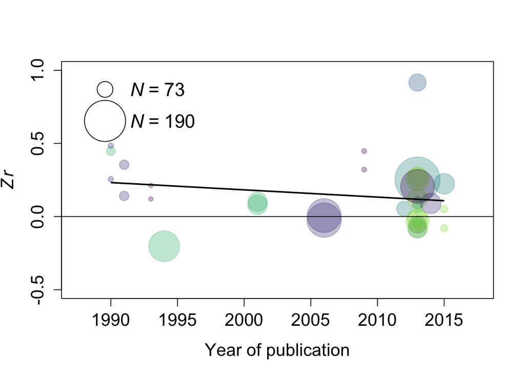

```r
# bubble plot

# Set colour palette (first six colour of the viridis palette. Last colour
# yellow is too light for a white background)

cols <- viridis(7, alpha = 0.3)[1:6]

# create image file to save to: png('bubblePlotFace.png', width = 15, height
# = 15, units = 'cm', res = 300)

symbols(x = data$Year, y = data$Zr, circles = data$w, inches = 0.3, xlab = "Year of publication",
    ylab = (expression(italic(Zr))), ylim = c(-0.5, 1), bg = cols[data$OverallDomain],
    fg = cols[data$OverallDomain], cex.axis = 1.4, cex.lab = 1.4)
abline(0, 0, lwd = 1)
legend(x = 1988.3, y = 1, legend = c((expression(italic(N) ~ "=" ~ 73)), "",
    (expression(italic(N) ~ "=" ~ 190))), pch = c(1, 1, 1), pt.cex = c(median(data$w/26),
    1, max(data$w/26)), bty = "n", cex = 1.5, col = c("black", "white", "black"),
    x.intersp = 1.5, y.intersp = 0.7)
clip(min(1990), max(2015), min(-3), max(3))
abline(lm(data$Zr ~ data$Year, na.action = na.omit), lwd = 2)
```

```r
# dev.off()

# publication bias analysis with residuals

# extract residuals first

# metafor can extract residuals BUT doesnt include random factors so here we
# need a bayesian analysis (MCMCglmm) which can produce this info too

data[, "centered_year"] <- centered_year

# set up prior We define as many Gs as there are random effects.
prior1 <- list(R = list(V = 1, nu = 0.002), G = list(G1 = list(V = 1, nu = 1,
    alpha.mu = 0, alpha.V = 1000), G2 = list(V = 1, nu = 1, alpha.mu = 0, alpha.V = 1000),
    G3 = list(V = 1, fix = 1)))

# getting observational level random effect
data$obs <- as.factor(1:dim(data)[1])
vc_matrix <- matrix(0, nrow = dim(data)[1], ncol = dim(data)[1])

# created variance-covariance matrix
rownames(vc_matrix) <- data$obs
colnames(vc_matrix) <- data$obs

diag(vc_matrix) <- 1/data$w
is.positive.definite(vc_matrix)
```

```
## [1] TRUE
```

```r
# prepared for MCMCglmm
invVC <- solve(vc_matrix)
invVC <- as(invVC, "dgCMatrix")

# NOTE! model estimation has been put in an inactive loop so that it doesn't
# need to re-run each time we run the script

if (FALSE) {


    modelMCMC <- MCMCglmm(Zr ~ centered_year, random = ~Paper + Paper:ParticipantSample +
        obs, data = data, nitt = 13000 * 10, thin = 10 * 10, burnin = 3000 *
        10, pr = T, ginverse = list(obs = invVC), prior = prior1)

    # save(modelMCMC, file = 'ModelMCMC_Face.RData')
}


load(file = "ModelMCMC_Face.RData")

# VCV is an automatically generated column in the model object, capturing
# estimate of random effect over iterations

# Extracting residuals

# Create predicted values from MCMCglmm model
Pred <- predict(modelMCMC, marginal = ~obs)
# Calculate residual by using the observed effect size minus the predicted
# effect size
es <- data$Zr - Pred
# Create precision values. The weight of the effect sizes based on sample
# size.
Prec <- 1/sqrt(1/data$w)  # Precision = 1/sqrt(V)

data2 <- data.frame(ES = es, Prec = Prec)

res11 <- rma(yi = es, sei = 1/Prec, method = "REML", data = data2)
summary(res11)
```

```
##
## Random-Effects Model (k = 34; tau^2 estimator: REML)
##
##   logLik  deviance       AIC       BIC      AICc
##  16.9596  -33.9192  -29.9192  -26.9262  -29.5192
##
## tau^2 (estimated amount of total heterogeneity): 0.0053 (SE = 0.0048)
## tau (square root of estimated tau^2 value):      0.0728
## I^2 (total heterogeneity / total variability):   26.82%
## H^2 (total variability / sampling variability):  1.37
##
## Test for Heterogeneity:
## Q(df = 33) = 40.9542, p-val = 0.1609
##
## Model Results:
##
## estimate      se     zval    pval    ci.lb   ci.ub
##  -0.0024  0.0249  -0.0960  0.9235  -0.0512  0.0464
##
## ---
## Signif. codes:  0 '***' 0.001 '**' 0.01 '*' 0.05 '.' 0.1 ' ' 1
```

```r
# Test symmetry of the funnel plot black points real studies, white points
# made up ones
Egger <- regtest(res11, model = "lm")
Egger
```

```
##
## Regression Test for Funnel Plot Asymmetry
##
## model:     weighted regression with multiplicative dispersion
## predictor: standard error
##
## test for funnel plot asymmetry: t = 0.7653, df = 32, p = 0.4497
```

```r
# Trim and fill nb this is like a paper with ink where you fold the paper in
# half and that basically adds effect sizes from each side to the other SO
# that its now symmetrical
TF1 <- trimfill(res11, estimator = "R0")
summary(TF1)
```

```
##
## Estimated number of missing studies on the left side: 4 (SE = 3.1623)
## Test of H0: no missing studies on the left side: p-val = 0.0312
##
## Random-Effects Model (k = 38; tau^2 estimator: REML)
##
##   logLik  deviance       AIC       BIC      AICc
##  11.3492  -22.6985  -18.6985  -15.4766  -18.3455
##
## tau^2 (estimated amount of total heterogeneity): 0.0144 (SE = 0.0071)
## tau (square root of estimated tau^2 value):      0.1200
## I^2 (total heterogeneity / total variability):   49.17%
## H^2 (total variability / sampling variability):  1.97
##
## Test for Heterogeneity:
## Q(df = 37) = 69.1754, p-val = 0.0010
##
## Model Results:
##
## estimate      se     zval    pval    ci.lb   ci.ub
##  -0.0320  0.0290  -1.1008  0.2710  -0.0889  0.0249
##
## ---
## Signif. codes:  0 '***' 0.001 '**' 0.01 '*' 0.05 '.' 0.1 ' ' 1
```

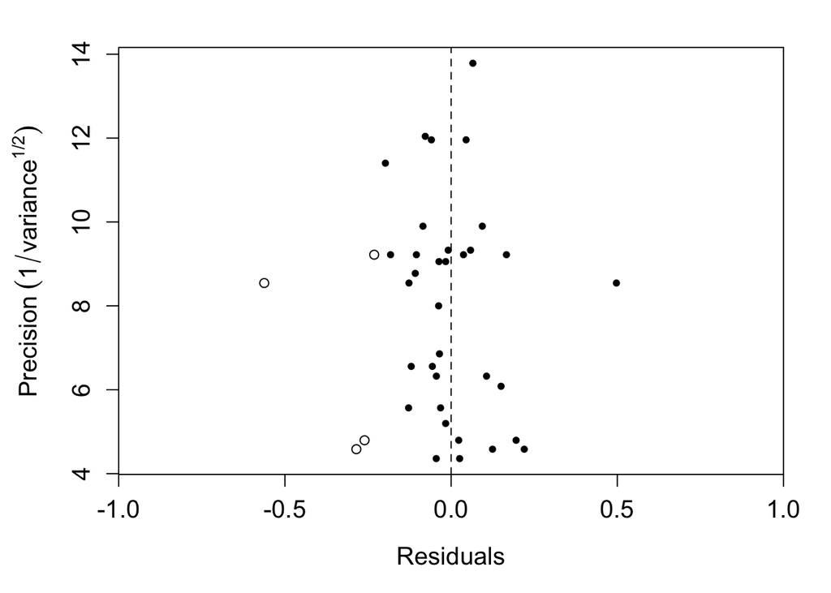

```r
# Funnel Plot with missing ESs imputed

# png('funnelPlotFace_2.png', width = 13, height = 11, units = 'cm', res =
# 300)

par(mar = c(5, 5, 2, 2))
plot(x = TF1$yi.f, y = sqrt(1/TF1$vi.f), pch = TF1$fill + 20, xlim = c(-1, 1),
    xaxs = "i", ylab = expression(Precision ~ (1/variance^"1/2")), xlab = "Residuals",
    cex.axis = 1.25, cex.lab = 1.25)
abline(v = 0, lty = "dashed")
```

```r
# dev.off()
```

## Other figures

### Forest plots

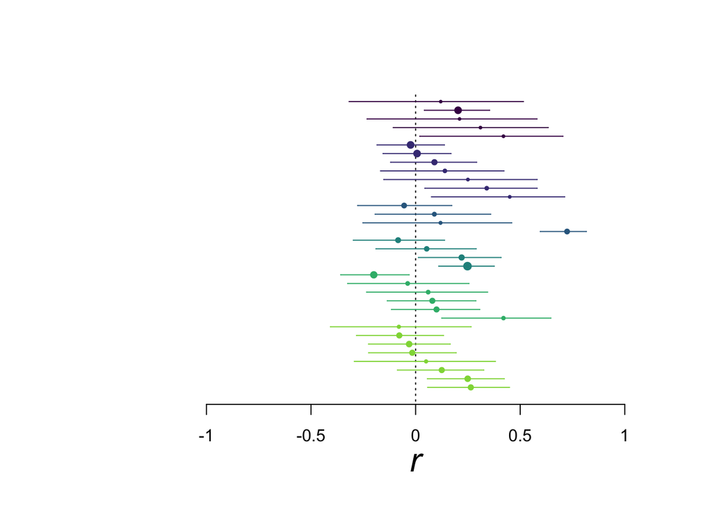

```r
#Forest plot of individual effect sizes

data$Yi <- data$Zr
data$Vi <- 1/data$w

#Create a new data frame that is ordered by the magnitude of the effect size
attach(data)
testdata <- data[order(Yi),]
detach(data)

#Run forest plot ordered by domain

#Create colour palette. First 6 colours of the viridis palette.

mypal <- viridis(7)[1:6]

#Create forest plot

#png("caterpillarPlotFace.png", width = 10.2, height = 13.3, units = "cm", res = 300)

forest(testdata$Yi, testdata$Vi,
       #xlim=c(-2.5,3.5),        ### adjust horizontal plot region limits
       subset=order(testdata$OverallDomain),
       slab=NA, annotate=FALSE, ### remove study labels and annotations
       efac=0,                  ### remove vertical bars at end of CIs
       pch=19,                  ### changing point symbol to filled circle
       col=mypal[testdata$OverallDomain],            ### change color of points/CIs
       transf=transf.ztor,      ###transform the effect sizes to Zr
       cex.lab=2, cex.axis=1,   ### increase size of x-axis title/labels
       xlab = expression(italic("r")), ###Label x-axis as r
       at=c(.50,-.50,-1,1,0),   ### Set x-axis ticks
       lty=c("solid","blank"))  ### remove horizontal line at top of plot
```

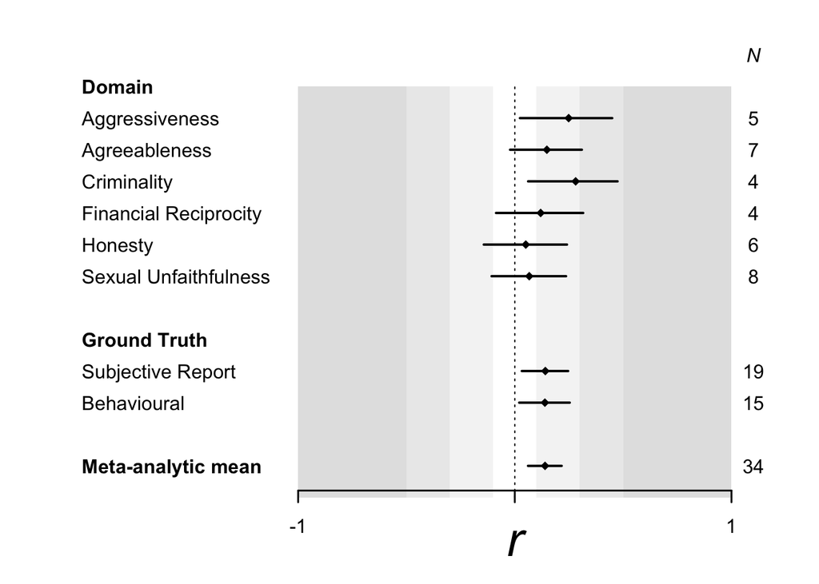

```r
#dev.off()

#Forest plot by moderator levels

forestdata <- read.csv("dataForPlotting_face.csv",na.strings="")

#ForestPlotMod.R is the modified r package that allows you to do the forest plot. Therefore, you need to load ForestPlotMod.R before you can do the forest plot. This package belongs to Shinichi Nakagawa.
source("ForestPlotMod.R")

### Draw the plotting region, the function draws a symetrical plot, thus it needs the
### largest possible effect as a positive value; e.g. if your biggest effect is -1.1, you
### might set the max.effect = 1.5. It takes the height you want your effect, if you want to
### plot ten points you might set height = 10, and the type of effect size you have as "d",
### "r" or "zr".

#png("forestPlotModeratorFace_2.png", width = 15.3, height = 12, units = "cm", res = 300)

#Giving the basic parameters of the plot (i.e. the x and y axes)
forest.plot(max.effect=1, height=13, type="r")

#This forest plot takes the mean and CI values from results of the analyses so that we don't have to change the values manually each time we decide to make changes to the analyses. Therefore, to plot each point, you need to load the results file and indicate which statistics to plot.

# Plot the intercept only model with final random effect structure
# Load the results file first
load(file = "M0_res_Face.RData")

# Indicate the y axis position of this data point (the higher the number, the higher the point on the y axis)
ypos=1
# Indicate what results to plot and insert labels
points(transf.ztor(res7$b), ypos, pch=18, cex=1.0)
arrows(transf.ztor(res7$ci.lb), ypos, transf.ztor(res7$ci.ub), ypos, code=0, lwd=2)
mtext("Meta-analytic mean", side=2, at=ypos, line=8.5, las=2, font=2, cex=1.0, adj = 0)
mtext(res7$k, side=4, at=ypos, line=0.2, las=2,  adj=0.5, cex=1.0)

### Plot univariate model with domain

load(file = "OverallDomain_res_Face.RData")

ypos=12
points(transf.ztor(res$b[1,]), ypos, pch=18, cex=1.0)
arrows(transf.ztor(res$ci.lb[1]), ypos, transf.ztor(res$ci.ub[1]), ypos, code=0, lwd=2)
mtext("Aggressiveness", side=2, at=ypos, line=8.5, las=2, font=1, cex=1.0, adj=0)
mtext(table(forestdata$OverallDomain)[1], side=4, at=ypos, line=0.2, las=2,  adj=0.5, cex=1.0)

ypos=11
points(transf.ztor(res$b[2,]), ypos, pch=18, cex=1.0)
arrows(transf.ztor(res$ci.lb[2]), ypos, transf.ztor(res$ci.ub[2]), ypos, code=0, lwd=2)
mtext("Agreeableness", side=2, at=ypos, line=8.5, las=2, font=1, cex=1.0, adj=0)
mtext(table(forestdata$OverallDomain)[2], side=4, at=ypos, line=0.2, las=2,  adj=0.5, cex=1.0)

ypos=10
points(transf.ztor(res$b[3,]), ypos, pch=18, cex=1.0)
arrows(transf.ztor(res$ci.lb[3]), ypos, transf.ztor(res$ci.ub[3]), ypos, code=0, lwd=2)
mtext("Criminality", side=2, at=ypos, line=8.5, las=2, font=1, cex=1.0, adj=0)
mtext(table(forestdata$OverallDomain)[3], side=4, at=ypos, line=0.2, las=2,  adj=0.5, cex=1.0)

ypos=9
points(transf.ztor(res$b[4,]), ypos, pch=18, cex=1.0)
arrows(transf.ztor(res$ci.lb[4]), ypos, transf.ztor(res$ci.ub[4]), ypos, code=0, lwd=2)
mtext("Financial Reciprocity", side=2, at=ypos, line=8.5, las=2, font=1, cex=1.0, adj=0)
mtext(table(forestdata$OverallDomain)[4], side=4, at=ypos, line=0.2, las=2,  adj=0.5, cex=1.0)

ypos=8
points(transf.ztor(res$b[5,]), ypos, pch=18, cex=1.0)
arrows(transf.ztor(res$ci.lb[5]), ypos, transf.ztor(res$ci.ub[5]), ypos, code=0, lwd=2)
mtext("Honesty", side=2, at=ypos, line=8.5, las=2, font=1, cex=1.0, adj=0)
mtext(table(forestdata$OverallDomain)[5], side=4, at=ypos, line=0.2, las=2,  adj=0.5, cex=1.0)

ypos=7
points(transf.ztor(res$b[6,]), ypos, pch=18, cex=1.0)
arrows(transf.ztor(res$ci.lb[6]), ypos, transf.ztor(res$ci.ub[6]), ypos, code=0, lwd=2)
mtext("Sexual Unfaithfulness", side=2, at=ypos, line=8.5, las=2, font=1, cex=1.0, adj=0)
mtext(table(forestdata$OverallDomain)[6], side=4, at=ypos, line=0.2, las=2,  adj=0.5, cex=1.0)

ypos=13
mtext(expression(bold("Domain")), side=2, at=ypos, line=8.5, las=2, font=2, cex=1.0, adj=0)

### Plot univariate model with ground truth measurement

load(file = "GTOp_res_Face.RData")
ypos=3
points(transf.ztor(res$b[1,]), ypos, pch=18, cex=1.0)
arrows(transf.ztor(res$ci.lb[1]), ypos, transf.ztor(res$ci.ub[1]), ypos, code=0, lwd=2)
mtext("Behavioural", side=2, at=ypos, line=8.5, las=2, font=1, cex=1.0, adj=0)
mtext(table(forestdata$GTOpRecode)[1], side=4, at=ypos, line=0.2, las=2,  adj=0.5, cex=1.0)

ypos=4
points(transf.ztor(res$b[2,]), ypos, pch=18, cex=1.0)
arrows(transf.ztor(res$ci.lb[2]), ypos, transf.ztor(res$ci.ub[2]), ypos, code=0, lwd=2)
mtext("Subjective Report", side=2, at=ypos, line=8.5, las=2, font=1, cex=1.0, adj=0)
mtext(table(forestdata$GTOpRecode)[2], side=4, at=ypos, line=0.2, las=2,  adj=0.5, cex=1.0)

ypos=5
mtext(expression(bold("Ground Truth")), side=2, at=ypos, line=8.5, las=2, font=2, cex=1.0, adj=0)

mtext(expression(italic(N)), side=4, at=14, adj=0.5, line=0.2, las=2)
```

```r
#dev.off()
```

## Supplementary analysis to check the effect of the number of raters on variance of effect sizes

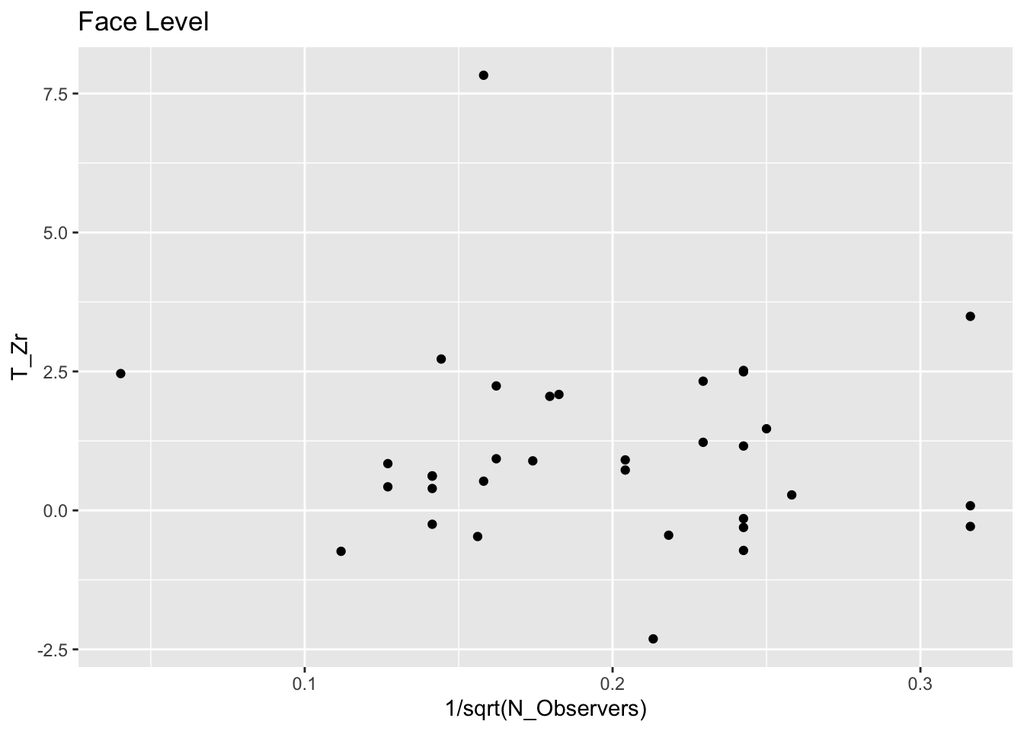

```r
# here we calculate T, which is the effect size Zr, accounting for the size
# of the N used to determine the df for that effect size. T is Zr divided by
# SE observer, sqrt(1/(N-3)) (which we can write as sqrt(1/w))
data$T_Zr <- data$Zr/(sqrt(1/data$w))

# Now we can plot T as a function of the secondary N (number of observers)

ggplot(data = data) + geom_point(mapping = aes(x = 1/sqrt(N_Observers), y = T_Zr)) +
    ggtitle("Face Level")
```

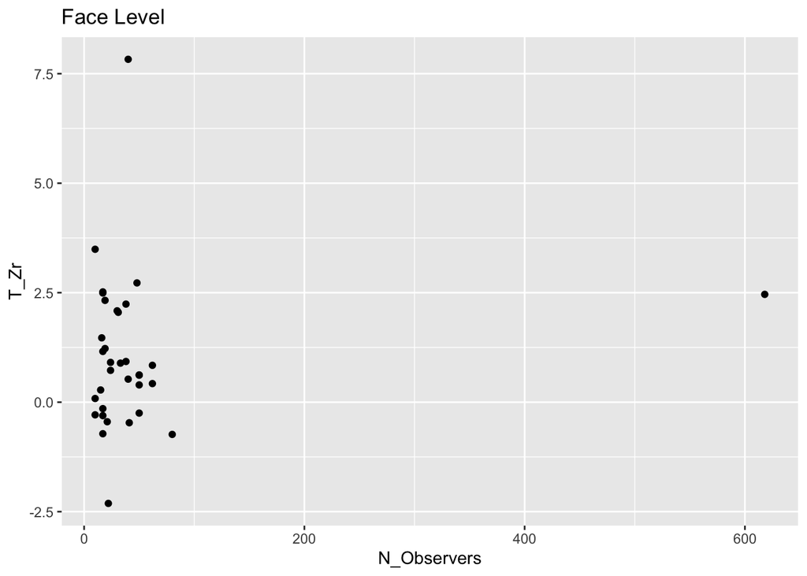

```r
ggplot(data = data) + geom_point(mapping = aes(x = N_Observers, y = T_Zr)) +
    ggtitle("Face Level")
```

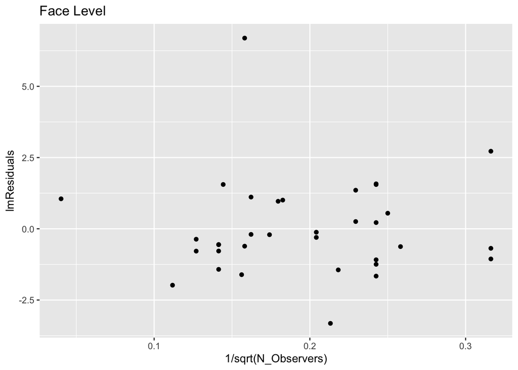

```r
# statistically test whether variance in T varies as N changes


# We're going to use 1/sqrt(N_[...]) a lot here, so let's make it its own
# variable:

data$N_Observers_Trans <- 1/sqrt(data$N_Observers)

# fit a linear regression model:
M.lm1 <- lm(T_Zr ~ N_Observers_Trans, data = data)

# now let's plot the residuals.  first we save the residuals into the data
# frames
data$lmResiduals <- M.lm1$residuals

# and now we can plot them:
ggplot(data = data) + geom_point(mapping = aes(x = 1/sqrt(N_Observers), y = lmResiduals)) +
    ggtitle("Face Level")
```

```r
# re-fit the linear models using gls so that we can compare the AIC:
M.lm <- gls(T_Zr ~ N_Observers_Trans, data = data)

# specify a fixed variance structure
vf1 <- varFixed(~N_Observers_Trans)

# fit the model with this new variance structure:
M.gls1 <- gls(T_Zr ~ N_Observers_Trans, weights = vf1, data = data)

# look at the model summaries
summary(M.lm)
```

```
## Generalized least squares fit by REML
##   Model: T_Zr ~ N_Observers_Trans
##   Data: data
##        AIC      BIC    logLik
##   134.0153 138.4125 -64.00767
##
## Coefficients:
##                       Value Std.Error    t-value p-value
## (Intercept)        1.502500  0.997496  1.5062717  0.1418
## N_Observers_Trans -2.320029  4.857253 -0.4776422  0.6362
##
##  Correlation:
##                   (Intr)
## N_Observers_Trans -0.954
##
## Standardized residuals:
##        Min         Q1        Med         Q3        Max
## -1.8995695 -0.5661365 -0.1914402  0.5704615  3.8302528
##
## Residual standard error: 1.747436
## Degrees of freedom: 34 total; 32 residual
```

```r
summary(M.gls1)
```

```
## Generalized least squares fit by REML
##   Model: T_Zr ~ N_Observers_Trans
##   Data: data
##        AIC      BIC    logLik
##   136.5833 140.9805 -65.29166
##
## Variance function:
##  Structure: fixed weights
##  Formula: ~N_Observers_Trans
##
## Coefficients:
##                       Value Std.Error   t-value p-value
## (Intercept)        1.955004  0.778854  2.510103  0.0173
## N_Observers_Trans -4.630193  4.298182 -1.077245  0.2894
##
##  Correlation:
##                   (Intr)
## N_Observers_Trans -0.925
##
## Standardized residuals:
##        Min         Q1        Med         Q3        Max
## -1.6862951 -0.5299117 -0.1669096  0.5369556  3.9444476
##
## Residual standard error: 4.211724
## Degrees of freedom: 34 total; 32 residual
```

```r
# compare the two models
anova(M.lm, M.gls1)
```

```
##        Model df      AIC      BIC    logLik
## M.lm       1  3 134.0153 138.4125 -64.00767
## M.gls1     2  3 136.5833 140.9805 -65.29166
```

```r
# what about the varpower variance structure?

vf2 <- varPower(form = ~N_Observers_Trans)

M.gls2 <- gls(T_Zr ~ N_Observers_Trans, weights = vf2, data = data)


anova(M.lm, M.gls2)
```

```
##        Model df      AIC      BIC    logLik   Test   L.Ratio p-value
## M.lm       1  3 134.0153 138.4125 -64.00767
## M.gls2     2  4 135.8660 141.7289 -63.93298 1 vs 2 0.1493786  0.6991
```

```r
# what about the varexp variance structure?

vf3 <- varExp(form = ~N_Observers_Trans)

M.gls3 <- gls(T_Zr ~ N_Observers_Trans, weights = vf3, data = data)

anova(M.lm, M.gls3)
```

```
##        Model df      AIC      BIC    logLik   Test   L.Ratio p-value
## M.lm       1  3 134.0153 138.4125 -64.00767
## M.gls3     2  4 135.6812 141.5442 -63.84062 1 vs 2 0.3341015  0.5633
```

```r
# what about the varconstpower variance structure?

vf4 <- varConstPower(form = ~N_Observers_Trans)

M.gls4 <- gls(T_Zr ~ N_Observers_Trans, weights = vf4, data = data)

anova(M.lm, M.gls4)
```

```
##        Model df      AIC      BIC    logLik   Test   L.Ratio p-value
## M.lm       1  3 134.0153 138.4125 -64.00767
## M.gls4     2  5 137.8660 145.1946 -63.93298 1 vs 2 0.1493786   0.928
```